# Load-cell calibration — data in wide form

Richard Layton

2016-08-24

```r
suppressPackageStartupMessages(library(dplyr))
library(tidyr)
library(stringr)
library(readr)
```

# Retrieve image of test setup

```r
url <- "https://raw.githubusercontent.com/DSR-RHIT/creating-reproducible-reports/gh-pages/resources/load-cell-setup-786x989px.png"
destination <- "resources/load-cell-setup-786x989px.png"
# don't download if the Internet is down, overwrites the file with empty
# possibly move the download to the setup file, do it once
# download.file(url, destination, mode = "wb")
```

The image shows that a force is applied vertically by hanging a weight on the eye hook. The thin-beam load cell deflects, causing the bridge to produce a voltage signal proportional to the applied force. Measurement units: input force (lb), output signal (mV).

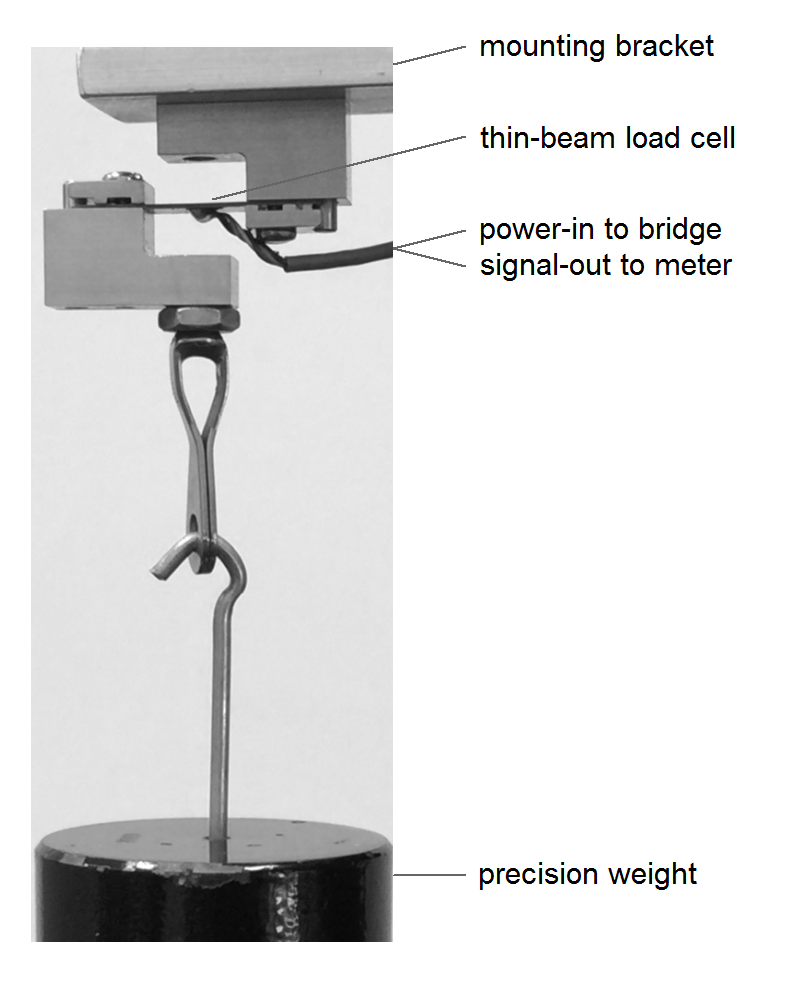

Figure 1. Load cell calibration test setup

```r
knitr::include_graphics("../resources/load-cell-setup-786x989px.png", dpi = 250)
```

# Examine the data

Download the data from the Internet repository.

```r
url <- "https://raw.githubusercontent.com/DSR-RHIT/creating-reproducible-reports/gh-pages/data/007_wide-data.csv"
destination <- "data/007_wide-data.csv"
# don't download if the Internet is down, overwrites the file with empty
# possibly move the download to the setup file, do it once
# download.file(url, destination)
```

Read the data as received and examine its structure.

```r
#data_received <- read_csv('data/007_wide-data.csv')
data_received <- read_csv('data/008_wide-data_6-cycles.csv')
## Parsed with column specification:
## cols(
##   test_point = col_character(),
##   input_lb = col_double(),
##   cycle_1 = col_double(),
##   cycle_2 = col_double(),
##   cycle_3 = col_double(),
##   cycle_4 = col_double(),
##   cycle_5 = col_double(),
##   cycle_6 = col_double()
## )
glimpse(data_received)
## Observations: 8
## Variables: 8
## $ test_point <chr> "2 up", "3 up", "4 up", "5 up", "4 dn", "3 dn", "2 ...
## $ input_lb   <dbl> 1.5, 2.5, 3.5, 4.5, 3.5, 2.5, 1.5, 0.5
## $ cycle_1    <dbl> NA, 51.1, 70.4, 88.8, 69.4, 49.5, 30.7, 8.7
## $ cycle_2    <dbl> 29.9, 49.4, 70.0, 91.6, 69.0, 50.1, 30.8, 10.9
## $ cycle_3    <dbl> 30.2, 49.7, 70.1, 89.5, 68.5, 49.8, 29.2, 10.6
## $ cycle_4    <dbl> 29.5, 49.6, 70.7, 91.4, 68.6, 49.2, 28.5, 10.7
## $ cycle_5    <dbl> 30.7, 48.5, 71.0, 91.2, 70.8, 50.6, 30.0, 9.5
## $ cycle_6    <dbl> 30.7, 51.6, NA, NA, NA, NA, NA, NA
```

The data object is a data frame.

```r
# look at the first few rows of the data set.
head(data_received)
```

```
## # A tibble: 6 × 8
##   test_point input_lb cycle_1 cycle_2 cycle_3 cycle_4 cycle_5 cycle_6
##        <chr>    <dbl>   <dbl>   <dbl>   <dbl>   <dbl>   <dbl>   <dbl>
## 1       2 up      1.5      NA    29.9    30.2    29.5    30.7    30.7
## 2       3 up      2.5    51.1    49.4    49.7    49.6    48.5    51.6
## 3       4 up      3.5    70.4    70.0    70.1    70.7    71.0      NA
## 4       5 up      4.5    88.8    91.6    89.5    91.4    91.2      NA
## 5       4 dn      3.5    69.4    69.0    68.5    68.6    70.8      NA
## 6       3 dn      2.5    49.5    50.1    49.8    49.2    50.6      NA
```

The data set has mV readings in several columns, designated *cycle_1*, *cycle_2*, etc. This is wide form and will have to be reshaped to long form for analysis.

The NA values in the first and last cycles represent are values that were not tested, per the ANSI/ISA standard. These NA observations can be deleted when we tidy the data.

A statistical summary of the numerical columns is useful for looking for data anomalies.

```r
# summary-stats except column 1
input_output_data <- data_received %>%
    select(-test_point)
summary(input_output_data)
```

```
##     input_lb      cycle_1         cycle_2         cycle_3
##  Min.   :0.5   Min.   : 8.70   Min.   :10.90   Min.   :10.60
##  1st Qu.:1.5   1st Qu.:40.10   1st Qu.:30.57   1st Qu.:29.95
##  Median :2.5   Median :51.10   Median :49.75   Median :49.75
##  Mean   :2.5   Mean   :52.66   Mean   :50.21   Mean   :49.70
##  3rd Qu.:3.5   3rd Qu.:69.90   3rd Qu.:69.25   3rd Qu.:68.90
##  Max.   :4.5   Max.   :88.80   Max.   :91.60   Max.   :89.50
##                NA's   :1
##     cycle_4         cycle_5         cycle_6
##  Min.   :10.70   Min.   : 9.50   Min.   :30.70
##  1st Qu.:29.25   1st Qu.:30.52   1st Qu.:35.92
##  Median :49.40   Median :49.55   Median :41.15
##  Mean   :49.77   Mean   :50.29   Mean   :41.15
##  3rd Qu.:69.12   3rd Qu.:70.85   3rd Qu.:46.38
##  Max.   :91.40   Max.   :91.20   Max.   :51.60
##                                  NA's   :6
```

# Create a data table for the report

A conventional calibration report includes a data table in wide form. All we have to do is format it nicely and save it to our `results` directory for later use.

Start with the data set without the test-point column (`input_output_data` created earlier) and edit the column names for printing to the client report.

```r
# begin editing the column names for the report printout
table_head <- colnames(input_output_data)
# ensure all strings are lower case for str_replace and str_detect
table_head <- tolower(table_head)
```

```r
# replace underscores with spaces
table_head <- str_replace(table_head, "_", " ")
# format the input units as (lb)
table_head <- str_replace(table_head, "lb", "(lb)")
```

```r
# add the output units to the cycle headings
cycle_true <- str_detect(table_head, "cycle")
cycle_head <- table_head[cycle_true]
cycle_head <- str_c(cycle_head, " (mV)")
```

```r
# reassign
table_head[cycle_true] <- cycle_head
```

```r
# substitute a capital letter for the first letter of each element
table_head <- gsub("^([a-z])", "\\U\\1", table_head, perl = TRUE)
```

Reassign the edited table heading to the data frame.

```r
# reassign
colnames(input_output_data) <- table_head
```

Print the table as it would appear in the report to check it.

```r
# print to check
kable(input_output_data, caption = "Table 1. Calibration data")
```

Table 1. Calibration data

| Input (lb) | Cycle 1 (mV) | Cycle 2 (mV) | Cycle 3 (mV) | Cycle 4 (mV) | Cycle 5 (mV) | Cycle 6 (mV) |
| --- | --- | --- | --- | --- | --- | --- |
| 1.5 | NA | 29.9 | 30.2 | 29.5 | 30.7 | 30.7 |
| 2.5 | 51.1 | 49.4 | 49.7 | 49.6 | 48.5 | 51.6 |
| 3.5 | 70.4 | 70.0 | 70.1 | 70.7 | 71.0 | NA |
| 4.5 | 88.8 | 91.6 | 89.5 | 91.4 | 91.2 | NA |
| 3.5 | 69.4 | 69.0 | 68.5 | 68.6 | 70.8 | NA |
| 2.5 | 49.5 | 50.1 | 49.8 | 49.2 | 50.6 | NA |
| 1.5 | 30.7 | 30.8 | 29.2 | 28.5 | 30.0 | NA |
| 0.5 | 8.7 | 10.9 | 10.6 | 10.7 | 9.5 | NA |

# Save to file

```r
# save active data set for subsequent scripts
write_csv(data_received, "data/01_calibr_data_active-report.csv")

# save tabulated data to results directory
write_csv(input_output_data, "results/01_calibr_data-wide.csv")
```